# Regressão linear na prática

## Dados da CAPES sobre avaliação da pós-graduação

A CAPES é um órgão do MEC que tem a atribuição de acompanhar a pós-graduação na universidade brasileira. Uma das formas que ela encontrou de fazer isso e pela qual ela é bastante criticada é através de uma avaliação quantitativa a cada x anos (era 3, mudou para 4).

Usaremos dados da penúltima avaliação da CAPES:

```r
cacc = read_projectdata()

glimpse(cacc)
```

```
## Observations: 73
## Variables: 31
## $ Instituição                  <int> NA, NA, NA, NA, NA, NA, NA, NA, N...
## $ Programa                     <chr> "INFORMÁTICA (12001015012P2)", "C...
## $ Nível                        <int> 5, 4, 3, 3, 3, 5, 4, 3, 3, 3, 5, ...
## $ Sigla                        <chr> "UFAM", "UFPA", "UFMA", "UEMA", "...
## $ `Tem doutorado`              <chr> "Sim", "Sim", "Não", "Não", "Não"...
## $ `Docentes colaboradores`     <dbl> 0.25, 5.50, 3.00, 6.25, 1.75, 2.0...
## $ `Docentes permanentes`       <dbl> 24.75, 14.00, 10.00, 14.00, 9.50,...
## $ `Docentes visitantes`        <dbl> 0.00, 0.00, 0.00, 0.00, 0.00, 0.7...
## $ `Resumos em conf`            <int> 20, 23, 15, 5, 4, 10, 6, 136, 0, ...
## $ `Resumos expandidos em conf` <int> 25, 24, 7, 10, 1, 68, 9, 13, 4, 6...
## $ `Artigos em conf`            <int> 390, 284, 115, 73, 150, 269, 179,...
## $ Dissertacoes                 <int> 108, 77, 50, 25, 31, 75, 60, 129,...
## $ Teses                        <int> 14, 0, 0, 0, 0, 24, 5, 0, 0, 0, 2...
```

[output cut: 18 more lines]

### Produção e produtividade de artigos

Uma das maneiras de avaliar a produção dos docentes que a CAPES utiliza é quantificando a produção de artigos pelos docentes. Os artigos são categorizados em extratos ordenados (A1 é o mais alto), e separados entre artigos em conferências e periódicos. Usaremos para esse lab a produção em periódicos avaliados com A1, A2 e B1.

```r
cacc = cacc %>%
  mutate(producao = (periodicos_A1 + periodicos_A2 + periodicos_B1),
         produtividade = producao / `Docentes permanentes`,
         mestrados = Dissertacoes,
         doutorados = Teses,
         mestrados_pprof = mestrados / `Docentes permanentes`,
         doutorados_pprof = doutorados / `Docentes permanentes`)
```

### EDA

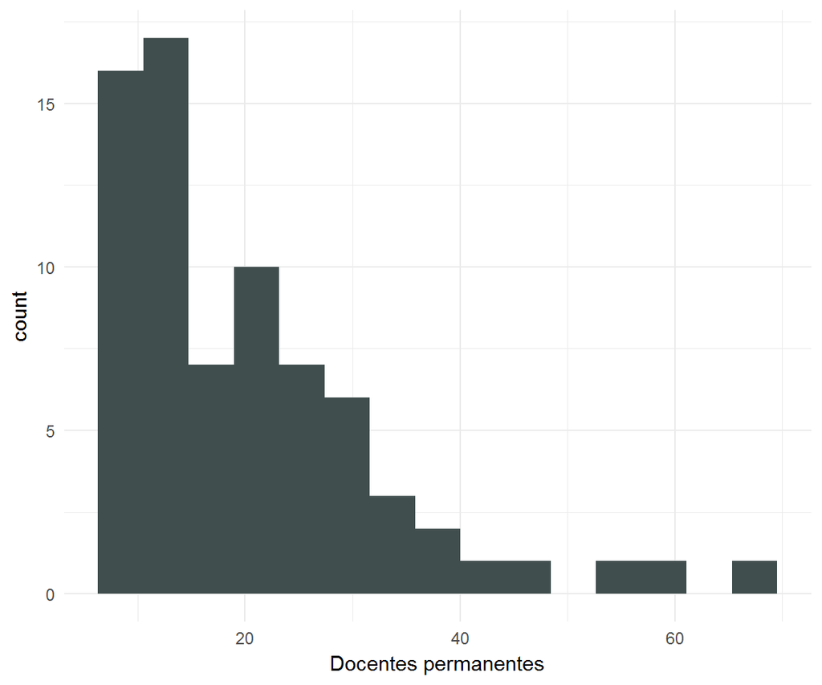

```r
cacc %>%
  ggplot(aes(x = `Docentes permanentes`)) +
  geom_histogram(bins = 15, fill = paleta[1])
```

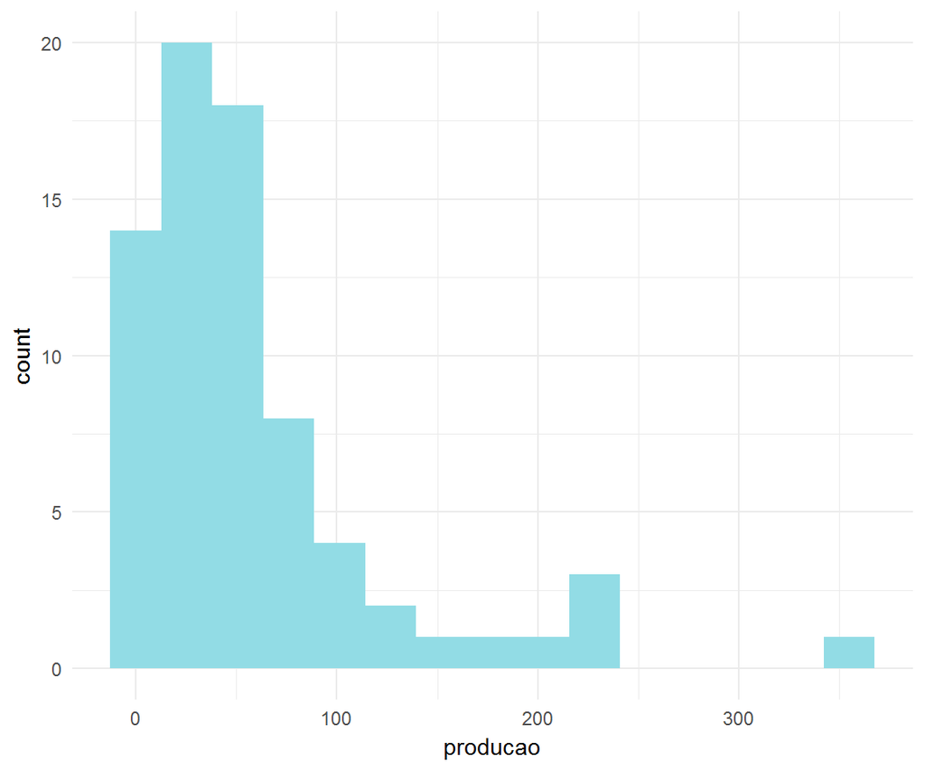

```r
cacc %>%
  ggplot(aes(x = producao)) +
  geom_histogram(bins = 15, fill = paleta[2])
```

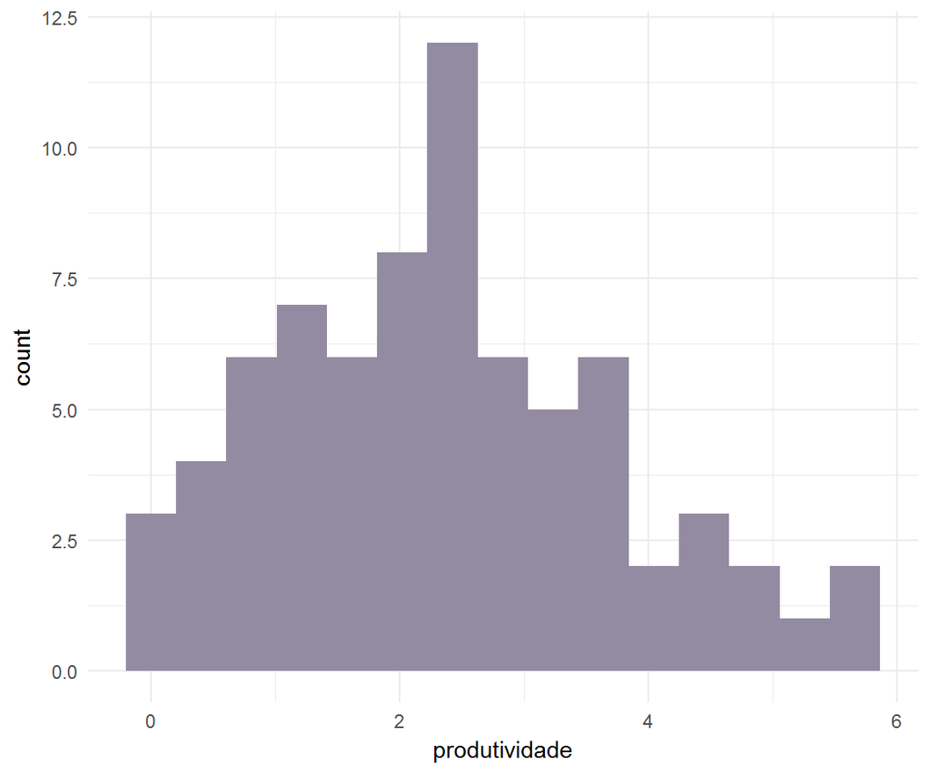

```r
cacc %>%
  ggplot(aes(x = produtividade)) +
  geom_histogram(bins = 15, fill = paleta[3])
```

Se quisermos modelar o efeito do tamanho do programa em termos de docentes (permanentes) na quantidade de artigos publicados, podemos usar regressão.

*Importante*: sempre queremos ver os dados antes de fazermos qualquer modelo ou sumário:

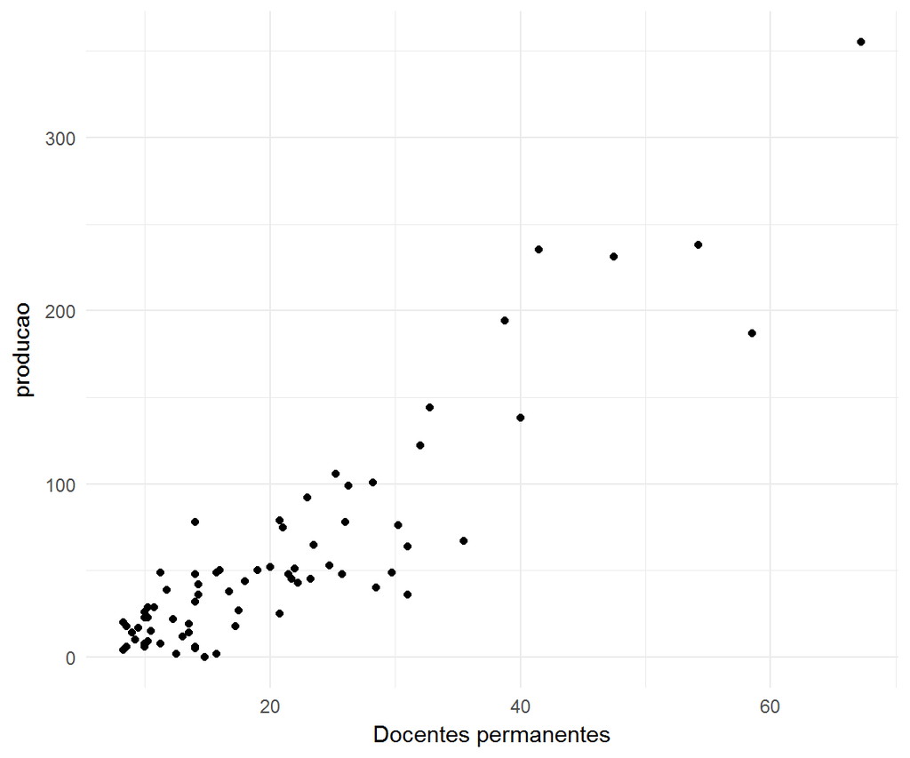

```r
cacc %>%
  ggplot(aes(x = `Docentes permanentes`, y = producao)) +
  geom_point()
```

Parece que existe uma relação. Vamos criar um modelo então:

```r
modelo1 = lm(producao ~ `Docentes permanentes`, data = cacc)

tidy(modelo1, conf.int = TRUE, conf.level = 0.95)
```

| term | estimate | std.error | statistic | p.value | conf.low | conf.high |
| --- | --- | --- | --- | --- | --- | --- |
| (Intercept) | -41.27309 | 6.5299245 | -6.320607 | 2.014731e-08 | -54.293387 | -28.252788 |
| `Docentes permanentes` | 4.81337 | 0.2725331 | 17.661601 | 1.088465e-27 | 4.269955 | 5.356786 |

```r
glance(modelo1)
```

| r.squared | adj.r.squared | sigma | statistic | p.value | df | logLik | AIC | BIC | deviance | df.residual |
| --- | --- | --- | --- | --- | --- | --- | --- | --- | --- | --- |
| 0.8145886 | 0.8119771 | 28.37407 | 311.9322 | 1.088465e-27 | 2 | -346.7883 | 699.5766 | 706.4479 | 57161.22 | 71 |

Para visualizar o modelo:

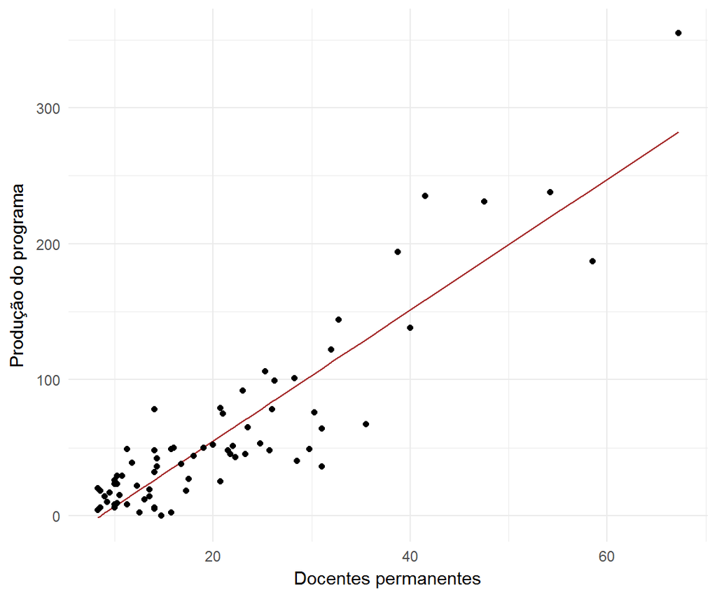

```r
cacc_augmented = cacc %>%
  add_predictions(modelo1)

cacc_augmented %>%
  ggplot(aes(x = `Docentes permanentes`)) +
  geom_line(aes(y = pred), colour = "brown") +
  geom_point(aes(y = producao)) +
  labs(y = "Produção do programa")
```

Se considerarmos que temos apenas uma amostra de todos os programas de pós em CC no Brasil, o que podemos inferir a partir desse modelo sobre a relação entre número de docentes permanentes e produção de artigos em programas de pós?

Regressão linear foi utilizada para analisar se a **quantidade de docentes permanentes** tem uma associação significativa com a **produção do programa** (quantidade total de artigos publicados em períodicos com qualis A1, A2 e B1). Os resultados da regressão indicam que um modelo com 1 preditor no formato $producao = -41.27 + 4.81 * docentesPermanentes$ explica 81,46% da variância da variável de resposta (R2 = 0.8146). $docentesPermanentes$, medida como a quantidade total de docentes permanentes, com valores entre [8.25, 67.25], tem uma relação significativa com o erro b = [4,27; 5,36], IC com 95%. O aumento de 1 unidade de $docentesPermanentes$ produz uma mudança de 4.81 na produção do programa.

Dito isso, o que significa a relação que você encontrou na prática para entendermos os programas de pós graduação no Brasil? E algum palpite de por que a relação que encontramos é forte?

O modelo encontrado mostra que há uma relação crescente entre a quantidade de docentes permanentes e a produção do programa, ou seja, em geral, quanto mais docentes maior será a produção do programa. Entretanto, segundo o modelo, a partir do aumento de 9 docentes é que a produção do programa tende a aumentar. Acredito que a relação é forte porque cada novo docente tende a produzir artigos, logo, quanto mais docentes maior será a produção do programa.

## Mais fatores

E se considerarmos também o número de alunos?

```r
modelo2 = lm(producao ~ `Docentes permanentes` + mestrados + doutorados, data = cacc)

tidy(modelo2, conf.int = TRUE, conf.level = 0.95)
```

| term | estimate | std.error | statistic | p.value | conf.low | conf.high |
| --- | --- | --- | --- | --- | --- | --- |
| (Intercept) | -14.3663077 | 7.45407703 | -1.927309 | 5.805909e-02 | -29.2367845 | 0.5041691 |
| `Docentes permanentes` | 3.4997112 | 0.45965441 | 7.613788 | 1.015822e-10 | 2.5827257 | 4.4166967 |
| mestrados | -0.1949515 | 0.08159627 | -2.389221 | 1.962240e-02 | -0.3577316 | -0.0321714 |
| doutorados | 1.0007711 | 0.18309265 | 5.465927 | 6.874998e-07 | 0.6355112 | 1.3660309 |

```r
glance(modelo2)
```

| r.squared | adj.r.squared | sigma | statistic | p.value | df | logLik | AIC | BIC | deviance | df.residual |
| --- | --- | --- | --- | --- | --- | --- | --- | --- | --- | --- |
| 0.8706642 | 0.8650409 | 24.03905 | 154.8316 | 1.416348e-30 | 4 | -333.6422 | 677.2845 | 688.7368 | 39873.45 | 69 |

Visualizar o modelo com muitas variáveis independentes fica mais difícil.

```r
para_plotar_modelo = cacc %>%
  data_grid(producao = seq_range(producao, 10), # Crie um vetor de 10 valores no range
            `Docentes permanentes` = seq_range(`Docentes permanentes`, 4),
            # mestrados = seq_range(mestrados, 3),
            mestrados = median(mestrados),
            doutorados = seq_range(doutorados, 3)) %>%
  add_predictions(modelo2)

glimpse(para_plotar_modelo)
```

```
## Observations: 120
## Variables: 5
## $ producao               <dbl> 0.00000, 0.00000, 0.00000, 0.00000, 0.0...
## $ `Docentes permanentes` <dbl> 8.25000, 8.25000, 8.25000, 27.91667, 27...
## $ mestrados              <int> 58, 58, 58, 58, 58, 58, 58, 58, 58, 58,...
## $ doutorados             <dbl> 0, 76, 152, 0, 76, 152, 0, 76, 152, 0, ...
## $ pred                   <dbl> 3.199123, 79.257725, 155.316327, 72.026...
```

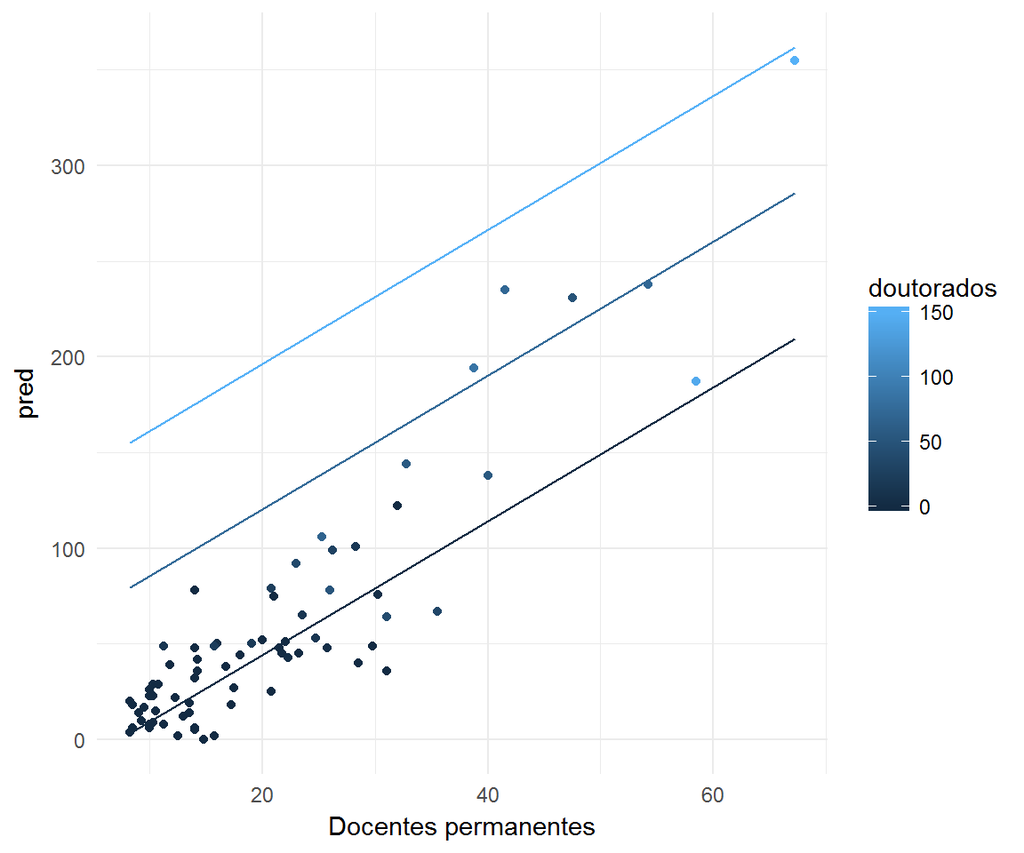

```r
para_plotar_modelo %>%
  ggplot(aes(x = `Docentes permanentes`, y = pred)) +
  geom_line(aes(group = doutorados, colour = doutorados)) +
  # facet_grid(. ~ as.factor(mestrados)) +
  geom_point(data = cacc, aes(y = producao, colour = doutorados))
```

Considerando agora esses três fatores, o que podemos dizer sobre como cada um deles se relaciona com a produção de um programa de pós em CC? E sobre o modelo? Ele explica mais que o modelo 1?

Regressão múltipla foi utilizada para analisar se a **quantidade de docentes permanentes**, a **quantidade de mestrandos** e a **quantidade de doutorandos** tem uma associação significativa com a **produção do programa** (quantidade total de artigos publicados em períodicos com qualis A1, A2 e B1). Os resultados da regressão indicam que um modelo com os 3 preditores no formato $producao = -14.37 + 3.50 * docentesPermanentes - 0.20 * mestrandos + 1.001 * doutorandos$ explicam 87,07% da variância da variável de resposta (R2 = 0.8707). $docentesPermanentes$, medida como a quantidade total de docentes permanentes, com valores entre [8.25, 67.25], tem uma relação significativa com o erro b = [2,58; 4,42], IC com 95%; $mestrandos$, medida como a quantidade total de alunos do mestrado, com valores entre [0, 433], tem uma relação significativa com o erro b = [-0,36; -0,03], IC com 95% e, por fim, $doutorandos$, medida como a quantidade total de alunos do doutorado, com valores entre [0, 152], tem uma relação significativa com o erro b = [0,63; 1,37], IC com 95%. O aumento de 1 unidade de $docentesPermanentes$ produz uma mudança de 3,5 na produção do programa, enquanto que $mestrandos$ diminui 0,2 e $doutorandos$ aumenta 1.001.

## Agora produtividade

Diferente de medirmos produção (total produzido), é medirmos produtividade (produzido / utilizado). Abaixo focaremos nessa análise. Para isso crie um modelo que investiga como um conjunto de fatores que você julga que são relevantes se relacionam com a produtividade dos programas. Crie um modelo que avalie como *pelo menos 3 fatores* se relacionam com a produtividade de um programa. Pode reutilizar fatores que já definimos e analizamos para produção. Mas cuidado para não incluir fatores que sejam função linear de outros já incluídos (ex: incluir A, B e um tercero C=A+B)

Produza abaixo o modelo e um texto que comente (i) o modelo, tal como os que fizemos antes, e (ii) as implicações - o que aprendemos sobre como funcionam programas de pós no brasil?.

```r
colnames(cacc)[which(names(cacc) == "Nível")] <- "Nivel"  #alterando o nome da coluna, porque deu erro ao usá-la

modelo3 = lm(produtividade ~ Nivel + mestrados + doutorados, data = cacc)

tidy(modelo3, conf.int = TRUE, conf.level = 0.95)
```

| term | estimate | std.error | statistic | p.value | conf.low | conf.high |
| --- | --- | --- | --- | --- | --- | --- |
| (Intercept) | -0.605322726 | 0.576879022 | -1.049306 | 2.976987e-01 | -1.756164886 | 0.545519435 |
| Nivel | 0.822829014 | 0.165500961 | 4.971748 | 4.645273e-06 | 0.492663631 | 1.152994397 |
| mestrados | -0.004024161 | 0.003035864 | -1.325541 | 1.893640e-01 | -0.010080543 | 0.002032221 |
| doutorados | 0.007934478 | 0.007582983 | 1.046353 | 2.990497e-01 | -0.007193159 | 0.023062114 |

```r
glance(modelo3)
```

| r.squared | adj.r.squared | sigma | statistic | p.value | df | logLik | AIC | BIC | deviance | df.residual |
| --- | --- | --- | --- | --- | --- | --- | --- | --- | --- | --- |
| 0.5259535 | 0.5053428 | 0.9652068 | 25.51844 | 3.219221e-11 | 4 | -98.94049 | 207.881 | 219.3333 | 64.28206 | 69 |

```r
para_plotar_modelo = cacc %>%
  data_grid(produtividade = seq_range(produtividade, 6),
            Nivel = seq_range(Nivel, 5),
            # mestrados = seq_range(mestrados, 3),
            mestrados = median(mestrados),
            doutorados = seq_range(doutorados, 3)) %>%
  add_predictions(modelo3)

glimpse(para_plotar_modelo)
```

```
## Observations: 90
## Variables: 5
## $ produtividade <dbl> 0.00000, 0.00000, 0.00000, 0.00000, 0.00000, 0.0...
## $ Nivel         <dbl> 3, 3, 3, 4, 4, 4, 5, 5, 5, 6, 6, 6, 7, 7, 7, 3, ...
## $ mestrados     <int> 58, 58, 58, 58, 58, 58, 58, 58, 58, 58, 58, 58, ...
## $ doutorados    <dbl> 0, 76, 152, 0, 76, 152, 0, 76, 152, 0, 76, 152, ...
## $ pred          <dbl> 1.629763, 2.232783, 2.835804, 2.452592, 3.055612...
```

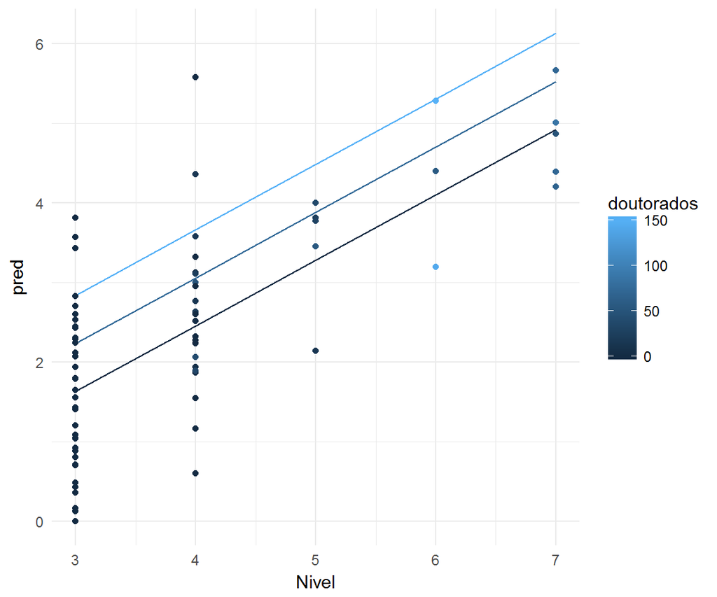

```r
para_plotar_modelo %>%
  ggplot(aes(x = Nivel, y = pred)) +
  geom_line(aes(group = doutorados, colour = doutorados)) +
  # facet_grid(. ~ as.factor(mestrados)) +
  geom_point(data = cacc, aes(y = produtividade, colour = doutorados))
```